# Estimation des coûts des séjours hospitaliers du point de vue de l’hôpital

Une étude à partir des données de l’ENCC

Antoine Filipovic-Pierucci

Dernière modification le 13 avril 2016

Le but de cet article est de discuter les possibilités d’estimer les coûts des séjours hospitaliers en MCO du point de vue de l’hôpital, à partir des données médico-administratives. Au final, la formule suivante est proposée :

Le reste de l’article présente la justification.

Durée moyenne de séjour selon l’ENCC :
$$DMS^{*} =
\begin{cases}
DMS & \text{Si } DMS \geq 1 \\
1 & \text{Si } DMS < 1
\end{cases}$$

Durée moyenne de séjour hors réanimation :
$$DMS_{HR} = DMS^{*} - DMS_{REA}$$

Coût clinique hors réanimation selon l’ENCC :
$$CCHR = DC + DSC + DSI$$
Avec $DC$ : Dépenses cliniques, $DSC$ : Dépenses SC, et $DSI$ : Dépenses SI.

Coût clinique quotidien hors réanimation :
$$CCHR_{Q} =
\begin{cases}
\frac{CCHR}{DMS_{HR}} & \text{Si } DMS_{HR} > 0 \\
0 & \text{Si } DMS_{HR} = 0
\end{cases}$$

Correction du coût clinique quotidien hors réanimation :
$$CCHR_{Q}^{*} =
\begin{cases}
CCHR_{Q} & \text{Si } 150 \geq CCHR_{Q} \geq 500 \\
150 & \text{Si } CCHR_{Q} < 150 \\
500 & \text{Si } CCHR_{Q} > 500
\end{cases}$$

Coût clinique quotidien en réanimation :
$$CCR_{Q} = 919$$

Utiliser les valeurs des forfaits spécifiques publiées au journal officiel pour les réanimations néonatales et pédiatriques.

Coût non clinique selon l’ENCC :
$$CNC = CCHS + TS - CC$$
Avec $CCHS$ : Coût complet hors structure, $TS$ : Total Structure et $CC$ : Dépense des activités cliniques.

Coût non clinique quotidien :
$$CNC_{Q} = \frac{CNC}{DMS}$$

Correction du coût non clinique quotidien :
$$CNC_{Q}^{*} =
\begin{cases}
CNC_{Q} & \text{Si } CNC_{Q} < 2500 \\
2500 & \text{Si } CNC_{Q} > 2500
\end{cases}$$

Durée totale de séjour selon le PMSI : $D_{T}$.

Correction de la durée totale de séjour :
$$D_{T}^{*} =
\begin{cases}
D_{T} & \text{Si } D_{T} \geq 1 \\
1 & \text{Si } D_{T} < 1
\end{cases}$$

Durée de séjour en réanimation selon le PMSI : $D_{REA}$, calculée à partir des suppléments.

Ne pas oublier les durées en réanimations noéonatales et pédiatriques ici non plus.

Durée de séjour hors-réanimation :
$$D_{HR} = D_{T}^{*} - D_{REA}$$

Correction de la durée de séjour hors-réanimation :
$$D_{HR}^{*} =
\begin{cases}
D_{HR} & \text{Si } D_{HR} \geq 0 \\
0 & \text{Si } D_{HR} < 0
\end{cases}$$

Calcul du coût total ($CT$) du séjour :
$$CT = D_{REA} \times CCR_{Q} + D_{HR}^{*} \times CCHR_{Q}^{*} + D_{T}^{*} \times CNC_{Q}^{*}$$

# Introduction

Afin d’estimer les coûts des séjours du point de vue de l’hôpital il est nécessaire de connaître avec la plus grande précision possible le coût pour l’établissement d’une journée d’hospitalisation pour chaque groupe homogène de malades (GHM). Pour obtenir des estimations plus précises il est également important d’essayer d’estimer les coûts de chaque type d’hospitalisation possibles dans un séjour (par exemple différencier l’hopitalisation dans un service clinique de l’hospitalisation en réanimation).

Toutefois la finesse des estimations est limitée d’une part par le type de données fournies par l’échelle national des coût commune (ENCC) et d’autre part par la qualité variables des données obtenues par l’ENCC. Le but de cet article est donc de proposer une méthodologie d’estimation des coûts des séjours du point de vue de l’hôpital.

Nous nous sommes basés sur l’ENCC de 2011 et les bases du PMSI MCO de 2011-2012.

# Description des données

Les résultats de l’ENCC fournis par l’agence technique de l’information sur l’hospitalisation (ATIH) contiennent une analyse détaillée des coûts par GHM et les caractéristiques statistiques par GHM de l’échantillon ayant permis d’estimer les coûts. Il existe deux ENCC différentes, pour le secteur ex-DGF (correspondant aux établissements publics et privés à but non lucratif) et le secteur ex-OQN (établissements privés à but lucratif).

Nous avons également extrait des bases du PMSI MCO des statistiques sur les GHMs, à partir de l’ensemble des séjours des années 2011 et 2012. Nous avons ensuite exclu les séjours non groupés et les séjours groupés dans un GHM qui n’existait pas dans l’ENCC (en pratique surtout des GHM rares dans le secteur ex-OQN). Dans l’ensemble de l’article, sauf mention contraire, nous considérons comme différents les GHMs ex-DGF des GHMs ex-OQN. Cette approche est justifiée car les coûts des séjours diffèrent entre les deux secteurs.

## Analyse des coûts

Dans l’ENCC les dépenses par GHM sont divisées en six sections :

- Dépenses des activités cliniques ;
- Dépenses médico-techniques ;
- Logistique et Gestion Générale ;
- Logistique médicale ;
- Charges directes ;
- Structure.

Chaque section est elle même divisée en plusieurs sous-sections. Pour la suite de l’analyse ce sont les sous-sections de la section *Dépense des activités cliniques* qui nous intéressent particulièrement. Cette dernière section est divisée en 4 sous-sections :

- Dépenses cliniques ;
- Dépenses SC ;
- Dépenses SI ;
- Dépenses REA.

## Caractéristiques statistiques

Les caratéristiques statistiques fournies par l’ATIH détaillent, pour chaque GHM, les caratéristiques de l’échantillon de l’ENCC qui a permis d’estimer les coûts. Les informations les plus intéressantes sont la Durée Moyenne de Séjour $DMS$ totale, la $DMS$ en réanimation et le nombre de séjours dans l’enchantillon. Nous avons également des informations sur la variabilité de l’estimation du coût total et sur le taux de sondage (c’est à dire la proportion des séjours nationaux de ce GHM qui ont été inclus dans l’échantillon ENCC).

# Estimation des coûts

L’idée générale pour estimer le coût d’un GHM par jour d’hospitalisation est simple : il faut diviser le coût du GHM par la $DMS$ du GHM. Cette méthode ne permet toutefois pas de détailler le coût des différents types d’hospitalisation (réanimation, soins intensifs, etc). L’assomption qui est donc faite implicitement est que chaque séjour a une durée de passage dans les différents types d’hopitalisation (en réanimation par exemple) égale à la durée de passage moyenne observée dans l’ENCC. Cette méthode ne permet pas de prendre en compte le fait qu’à durée de séjour équivalente, un patient qui séjourne plus longtemps en réanimation coûte probablement plus cher à l’hôpital qu’un patient qui y séjourne moins longtemps.

Pour éviter ce problème, il faut donc estimer séparément le coût par jour de chaque type d’hospitalisation (clinique, surveillance continue, soins intensifs et réanimation). Mais il faut aussi garder à l’esprit que certains coûts (dépenses médico-techniques par exemple) sont attribués à l’ensemble du séjour, sans être attachées à un type d’hospitalisation particulier. Nous appelerons ces dépenses le coût non-clinique $CNC$, par opposition au coût clinique $CC$.

## Coûts cliniques

Les coûts par type d’hospitalisation sont fournis pour tous les GHMs par l’ENCC. Par contre les durées moyennes de séjour en hospitalisation clinique, en surveillance continue et en soins intensifs ne sont pas estimable car l’ENCC ne donne que la $DMS$ totale $DMS_{T}$ et la $DMS$ en réanimation $DMS_{REA}$. Il est donc impossible de diviser les coûts par types d’hospitalisation par les $DMS$ correspondantes.

Il faut donc calculer un coût d’hospitalisation par jour en hors-réanimation en combinant l’hospitalisation clinique, la surveillance continue, et les soins intensifs. Cette approche fait donc l’hypothèse (fausse) que chaque séjour dont on calcule le coût est resté en hospitalisation clinique, en surveillance continue et en soins intensifs pendant la même durée que la moyenne de l’échantillon ENCC pour ce GHM.

Le coût clinique hors réanimation $CCHR$ peut être estimé selon la formule (1).

1. $$CCHR = DC + DSC + DSI$$

Avec $DC$ : Dépenses cliniques, $DSC$ : Dépenses SC et $DSI$ : Dépenses SI.

Avec l’ENCC seule la $DMS$ hors-réanimation (comprenant l’hospitalisation clinique, la surveillance continue et les soins intensifs) est calculable selon la formule (2).

2. $$DMS_{HR} = DMS_{T} - DMS_{REA}$$

Le coût clinique quotidien hors-réanimation $CCHR_{Q}$ est calculé selon la formule (3).

3. $$CCHR_{Q} =
   \begin{cases}
   \frac{CCHR}{DMS_{HR}} & \text{Si } DMS_{HR} > 0 \\
   0 & \text{Si } DMS_{HR} = 0
   \end{cases}$$

Le coût complet moyen du passage en réanimation $CCR$ est donné par la colonne *Dépenses REA*. La $DMS_{REA}$ est disponible dans l’ENCC. Il est donc possible de calculer le coût clinique quotidien en réanimation $CCR_{Q}$ avec la formule (4).

4. $$CCR_{Q} = \frac{CCR}{DMS_{REA}}$$

Avec $CCR$ : Dépenses REA.

## Coûts non cliniques

Le reste des coûts correspondent à des dépenses non attachées à un type d’hospitalisation particulier (par exemple l’imagerie ou la biologie), et des dépenses non liées directement au séjour (par exemple des dépenses immobilières de l’hôpital). Ces dernières sont réparties par l’ENCC entre les séjours selon des clefs de ventilations multiples et complexes.

Le coût total non clinique $CNC$ peut être calculé par la formule (5).

5. $$CNC = CCHS + TS - CC$$

Avec $CC$ : Dépense des activités cliniques, $CCHS$ : Coût complet hors structure et $TS$ : Total Structure.

Pour obtenir un coût quotidien $CNC_{Q}$ il suffit ensuite de diviser le $CNC$ par la $DMS_{T}$, formule (6).

Il est possible que certaines dépenses non cliniques ne soient pas ventilées sur les séjours en fonction des durées de séjours observées dans l’ENCC. Dans ce cas il est incorrect d’inclure ces dépenses dans un coût quotidien, car elles ne seraient engagées qu’une seule fois au cours du séjour. Si quelqu’un veut s’amuser à décortiquer le guide méthodologique de l’ENCC pour comprendre les clefs de ventilation des coûts de structure ne vous génez pas !

6. $$CNC_{Q} = \frac{CNC}{DMS_{T}}$$

## Calcul du coût total du séjour

Pour calculer le coût du séjour il faut multiplier les différents coûts quotidiens par la durée pendant laquelle ces dépense ont été engagées. La durée totale de séjour $D_{T}$ est disponible dans les bases du PMSI. La durée de séjour en réanimation $D_{REA}$ correspond au nombre de suppléments de réanimation. La durée de séjour hors-réanimation $D_{HR}$ est égale à la durée totale de séjour $D_{T}$ moins la durée de séjour en réanimation $D_{REA}$, voir formule (7).

7. $$D_{HR} = D_{T} - D_{REA}$$

La formule (8) peut donc être utilisée pour calculer le coût total $C$ du séjour.

8. $$C = D_{REA} \times CCR_{Q} + D_{HR} \times CCHR_{Q} + D_{T} \times CNC_{Q}$$

# Problème des durées de séjour à zéro

La démarche présentée plus haut est purement théorique. Certaines caractéristiques du PMSI et de l’ENCC font qu’en pratique elle ne peut pas être appliquée aussi simplement.

Certains types de séjours du PMSI peuvent avoir une durée de séjour à zéro (si le patient n’a pas passé la nuit à l’hôpital). Ceci pose les problèmes suivants :

- Si tous les séjours de l’ENCC ont une durée de zéro jours, la DMS sera égale à zéro et diviser les coûts par des DMS nulles posera problème ;
- Si une partie des séjours de l’ENCC ont une durée de zéro jours diviser des coûts par la $DMS$ donnera un résultat incorrect (cette approche équivaut à considérer que les séjours de zéro jours n’ont rien coûté) ;
- Même si nous avions un coût quotidien correct, la méthode actuelle prédirait un coût nul pour les séjours de zéro jours ;
- Il est probable qu’une journée d’hospitalisation sans nuit (séjour de zéro jours) coûte moins qu’une journée d’hospitalisation avec nuit, il est donc également incorrect de considérer les séjours de zéro jours comme des séjours de un jour ;
- Si un patient n’a pas passé la nuit à l’hôpital mais est passé en réanimation dans la journée, la durée de séjour hors réanimation calculée sera de $-1$.

Il est donc important d’identifier l’étendue des problèmes et les GHM concernés, et de proposer des méthodes de calcul alternatives pour ces GHM.

## Etendue du problème

Nous avons utilisé l’ensemble des données du PMSI MCO des année 2011 et 2012. Nous avons calculé la proportion de séjours avec une durée égale à zéro, par GHM et selon le mode de valorisation (ex-DGF ou ex-OQN).

Table 1 : Répartition des GHM selon la durée de séjour (M : mélange de séjours de 0 jours et de plus de 0 jours) et la sévérité.

| Séjour | 0-DGF | >0-DGF | M-DGF | 0-OQN | >0-OQN | M-OQN |
| --- | --- | --- | --- | --- | --- | --- |
| 1 | 0 | 69 | 31 | 0 | 74 | 26 |
| 2 | 0 | 100 | 0 | 0 | 100 | 0 |
| 3 | 0 | 100 | 0 | 0 | 100 | 0 |
| 4 | 0 | 100 | 0 | 0 | 100 | 0 |
| A | 0 | 31 | 69 | 0 | 38 | 62 |
| B | 0 | 100 | 0 | 0 | 100 | 0 |
| C | 0 | 100 | 0 | 0 | 100 | 0 |
| D | 0 | 100 | 0 | - | - | - |
| E | 0 | 20 | 80 | 0 | 0 | 100 |
| J | 100 | 0 | 0 | 100 | 0 | 0 |
| T | 32 | 0 | 68 | 25 | 0 | 75 |
| Z | 0 | 29 | 71 | 0 | 33 | 67 |

La table 1 montre selon le type ou la gravité du GHM la proportion de GHM avec des durées de séjours exclusivement à zéro (0-DGF et 0-OQN), exclusivement différentes de zéro (>0-DGF et >0-OQN), ou composées d’un mélange de ces deux cas (M-DGF et M-OQN). Les résultats sont équivalents dans les secteurs ex-DGF et ex-OQN. Seuls les GHMs de type J avaient des durées de séjours exclusivement à zéro jours. Inversement, seuls les GHMs de sévérité 2, 3, 4, B, C et D avaient des durées de séjours exclusivement supérieures à zéro. Les GHMs de sévérité 1 et A et de type E, T et Z avaient une partie de leurs séjours avec une durée à zéro.

Pour ces dernières catégories de GHMs nous allons essayer de calculer à quel point les durées de séjours sont hétérogènes entre GHMs, et si nécessaire trouver d’autres facteurs permettant d’identifier les GHMs problématiques. Pour cela nous pouvons calculer la $DMS$ des patients qui sont restés plus de zéro jours en utilisant la formule (9), où $P_{0}$ est la proportion de patients avec une durée de séjour à zéro pour le GHM.

9. $$DMS_{cor} = DMS \times \frac{1}{(1 - P_{0})}$$

Avec les informations $P_{0}$ et $DMS_{cor}$, nous pouvons essayer d’établir une typologie des GHMs problématiques :

- Plus de 95% des séjours ont une durée à zéro, dans ce cas peu importe la DMS des patients restés plus longtemps (situation 1) ;
- Moins de 5% des séjours ont une durée à zéro, dans ce cas seule la $DMS$ compte (situation 2) ;
- Entre 5% et 95% des séjours ont une durée à zéro, dans ce cas le calcul est plus compliqué.

Le dernier cas peut en fait être divisé en deux catégories :

- La $DMS_{cor}$ des individus qui sont restés plus d’un jour est proche de 1 (situation 3) ;
- La $DMS_{cor}$ est importante (situation 4).

Comme le montre la table 2 la répartition des différentes situations varie grandement selon le type de séjour. Alors que pour les séjours de sévérité A et 1 la situation 2 domine, les séjours de type E, T et Z sont nettement plus panachés. Enfin seuls les séjours de type Z ont une proportion non négligeable de situation 4, la plus compliquée à gérer.

Table 2 : Proportion des situations selon les types de séjours.

|  | 1 | A | E | T | Z |
| --- | --- | --- | --- | --- | --- |
| 1 | 1 | 0 | 17 | 30 | 20 |
| 2 | 88 | 93 | 25 | 1 | 34 |
| 3 | 0 | 0 | 50 | 64 | 18 |
| 4 | 12 | 7 | 8 | 4 | 28 |

## Solutions proposées

En utilisant les résultats précédents, nous pouvons proposer une marche à suivre qui, au prix de quelques approximations, permet d’estimer simplement les coûts. La principale approximation que nous utiliserons est de considérer que un séjour de zéro jour a le même coût qu’un séjour d’un jour pour un GHM où des durées de séjour de zéro jours coexistent avec des durées de séjour plus longues. En effet dans cette situation le coût spécifique d’un séjour de zéro jours n’est pas identifiable à partir de l’ENCC. En réalité le coût d’un séjour de zéro jours est probablement inférieur au coût d’un séjour d’un jour.

*Type 2, 3, 4, B, C et D* : Pour les GHMs de type 2, 3, 4, B, C et D la formule classique de l’équation (8) est applicable sans modification car il n’y a pas de séjours de zéro jours.

*Type J* : Pour les GHMs de type J les individus sont tous restés une seule journée. Le $CCHR_{Q}$ se calcule donc comme dans l’équation (3), mais en utilisant une $DMS$ modifiée égale à 1 dans tous les cas. Le $CCR_{Q}$ se calcule de la même manière, voir formule (4). Ensuite la formule (10) doit être appliquée.

10. $$C =
    \begin{cases}
    CCHR_{Q} + CNC & \text{Si } D_{REA} = 0 \\
    CCR_{Q} + CNC & \text{Si } D_{REA} > 0
    \end{cases}$$

*Type 1 et A* : Pour les GHMs de type 1 et A, la situtation 2 (presque pas de durées de séjours à zéro) domine largement (voir table 2). Nous allons donc considérer qu’il n’y a pas de séjours de zéro jours. Les méthodes d’estimations des coûts sont donc les mêmes que celle décrites dans l’équation (8).

Toutefois pour éviter des problèmes d’estimation dans les rares GHMs où cette assomption ne fonctionne pas, une correction est nécessaire, il faut recalculer la $DMS$ de ces GHMs pour éviter les $DMS < 1$. Nous allons considérer que les individus hospitalisés zéro jour ont le même coût que les individus hospitalisés un jour. La méthode exacte de modification de la $DMS$ consiste à ajouter à la $DMS$ la proportion $P_{0}$ d’individus qui ont une durée de séjour égale à zéro, équation (11).

11. $$DMS_{mod} = DMS + P_{0}$$

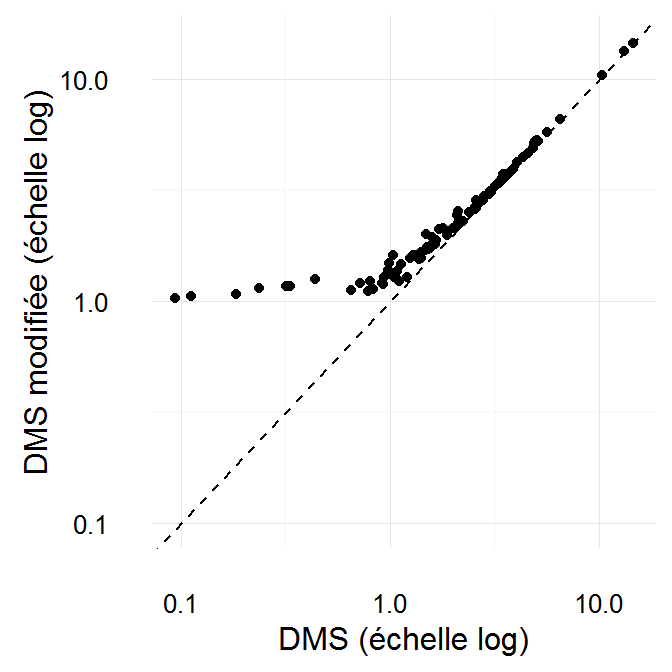

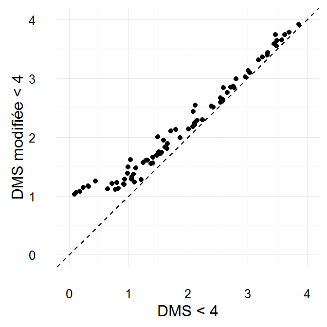

Figure 1 : Effet de la modification de la $DMS$.

Mais comme le montre la figure 1 cette correction a en pratique l’effet de remonter les $DMS$ inférieures à 1 à une valeur légèrement supérieure à 1 Les DMS supérieures à un sont également augmentées par la modification, mais l’ampleur relative de cette augmentation est faible, nous allons donc la négliger.

En pratique, pour les séjours de type 1 et A, nous pouvons donc proposer la formule (12) pour estimer le coût clinique quotidien hors réanimation ($CCHR_{Q}$) du séjour.

12. $$CCHR_{Q} = \frac{CCHR}{DMS^{*}_{HR}}$$
    Avec :
    $$DMS^{*}_{HR} = DMS^{*} - DMS_{REA}$$
    Et :
    $$DMS^{*} =
    \begin{cases}
    DMS & \text{Si } DMS \geq 1 \\
    1 & \text{Si } DMS < 1
    \end{cases}$$

De même le coût non clinique quotidien ($CNC_{Q}$) peut être estimé par la formule (13), avec $DMS^{*}$ définit dans l’équation (12).

13. $$CNC_{Q} = \frac{CNC}{DMS^{*}}$$

L’estimation du coût clinique quotidien en réanimation ($CCR_{Q}$) quant à elle ne change pas par rapport à l’équation (4).

*Type T* : Pour les séjours de type T, deux situation coexistent (voir table 2), la situation 1 (uniquement des séjours de zéro jours) et la situation 3 (mélange de séjours de zéro jours et de DMS proches d’un jour). Si nous faisons les approximations que les séjours de zéro jours et d’un jours ont le même coût et que les $DMS$ légèrement supérieures à un sont égales à un, alors toutes les DMS peuvent être considérées comme égales à un. L’estimation du coût du séjour du point de vue de l’hôpital est donc la même que pour les séjours de type J, voir équation (10). Cette méthode produit des estimations incorrectes pour seulement 5% des GHMs de cette catégorie.

*Type E* : Pour les séjours de type E les situations 1 (presque que des séjours de zéro jours), 2 (presque pas de séjours de zéro jours) et 3 (mélange de séjours de zéro jours et de $DMS$ proches d’un jour) coexistent (voir table 2). Ces situations sont facilement différentiables car les $DMS$ des GHMs en situation 2 sont supérieures ou presque égales à un (en pratique un seuil à 0.95 fonctionne bien) alors que les DMS des GHMs en situation 1 et 3 sont largement inférieures à un.

En pratique, si on considère qu’un séjour de zéro jours a le même coût qu’un séjour d’un jour, le coût total du séjour pour les séjours de type E peut être estimé par la meme méthode que les séjours de type 1 et A, équation (12), si la DMS est supérieure à 0.95. Dans le cas contraire le coût du séjour peut être estimé par la même méthode que les séjours de type J, équation (10). Cette méthode d’estimation produit des résultats incorrects pour 8% des GHMs.

*Type Z* : Pour les séjours de type Z l’estimation est plus complexe. Pas de solution pour l’instant.

*Synthèse* : En pratique, l’ensemble de ces modifications peut être implémenté très simplement en utilisant ces condition avant d’appliquer les équations (6) et (8).

$$DMS^{*} =
\begin{cases}
DMS & \text{Si } DMS \geq 1 \\
1 & \text{Si } DMS < 1
\end{cases}$$

$$D_{T}^{*} =
\begin{cases}
D_{T} & \text{Si } D_{T} \geq 1 \\
1 & \text{Si } D_{T} < 1
\end{cases}$$

$$D_{HR}^{*} =
\begin{cases}
D_{HR} & \text{Si } D_{HR} \geq 0 \\
0 & \text{Si } D_{HR} < 0
\end{cases}$$

# Problème des estimations de mauvaise qualité

Quand l’effectif de l’echantillon ENCC est faible pour un GHM donné, les estimations peuvent être de mauvaise qualité. En pratique cette situation est rare pour l’estimation du coût d’ensemble d’un GHM, mais elle devient plus fréquente pour l’estimation des coûts de réanimation. En effet il existe de nombreux GHMs où les passages en réanimation sont rares. Dans ce cas, même si l’effectif total du GMH dans l’ENCC est important, l’effectif sur lequel sont basés les estimations des coûts de réanimation est faible.

Nous allons explorer d’abord le problème de l’estimation du coût total du GHM, puis le problème de l’estimation des coûts en réanimation.

## Etendue du problème

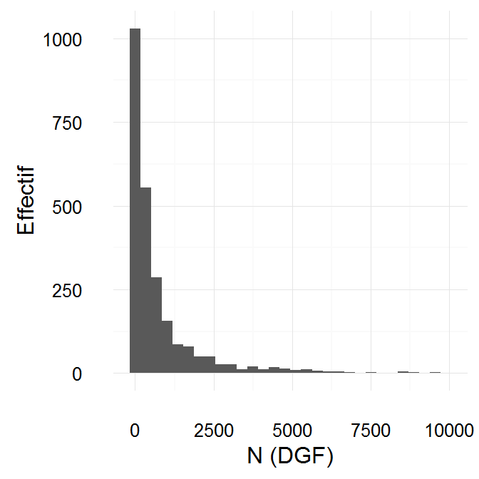

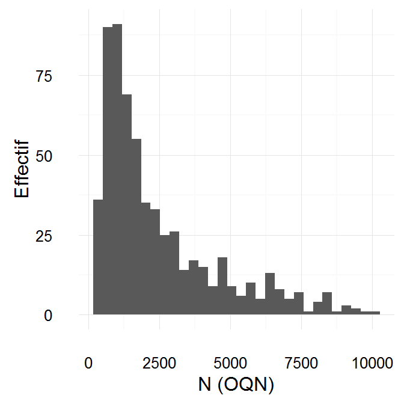

Figure 2 : Nombre de séjours par GHM dans l’ENCC (GHM avec plus de 10 000 séjours masqués)

Le nombre de patients par GHM dans l’échantillon ENCC $N_{ENCC}$ semble suivre à peu près une loi log-normale (voir figure 2). Dans l’ENCC ex-DGF 62% des GHMs ont un effectif inférieur à 500. Par contre dans l’ENCC ex-OQN seuls 5% des GHMs ont un effectif inférieur à 500.

Est-ce qu’ils ont supprimé les GHMs OQN avec des effectifs trop faibles, ou bien est-ce que les GHM OQN sont moins hétérogènes ? Probablement un mélange des deux. Voir explications méthodo de l’ENCC sur site ATIH.

Le problème des faibles effectifs se pose donc principalement dans le secteur ex-DGF. Sauf dans le cas où la variance inter-séjours est très faible, un effectif faible entraîne une estimation imprécise du coût moyen de séjour.

Ceci est vrai même dans le cas où l’ENCC a échantillonné de façon exhaustive ou quasi-exhaustive un GHM rare. S’il est vrai que la moyenne calculée ainsi est la vrai moyenne du coût du GHM sur l’année d’observation, il n’en reste pas moins que cette moyenne est susceptible de varier grandement sur de nouvelles observations. Or l’estimation des coûts est faite dans une perspective prédictive et non descriptive.

Pour mesurer l’étendue du problème de mauvaise estimation du coût total nous pouvons explorer la variabilité des estimations des coûts cliniques quotidiens hors réanimation $CCHR_{Q}$, voir équation (3), et des coûts non cliniques quotidiens $CNC_{Q}$, voir équation (6). L’incertitude d’estimation des coûts cliniques quotidiens en réanimation ($CCR_{Q}$, voir équation (4) dépend également de la proportion de séjours du GHM avec un passage en réanimation. Nous ne l’explorerons donc pas immédiatement.

$CCHR_{Q}$ et $CNC_{Q}$ : Pour calculer ces coûts nous allons utiliser les méthodes de correction décrites dans la section précédente pour prendre en compte le problème des durées de séjour à zéro.

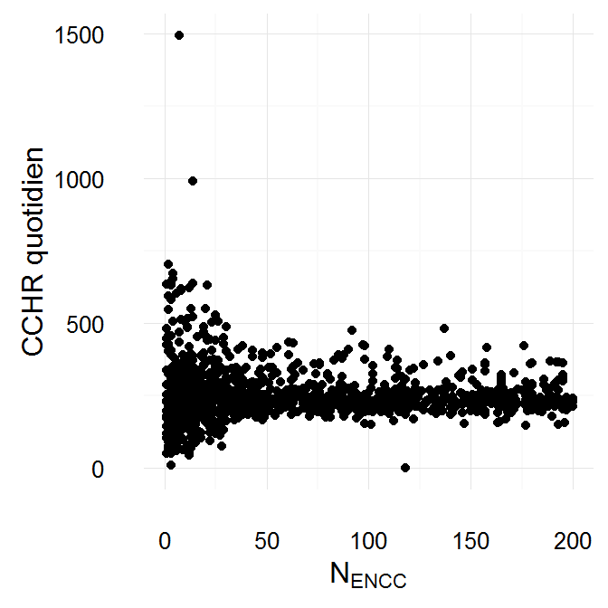

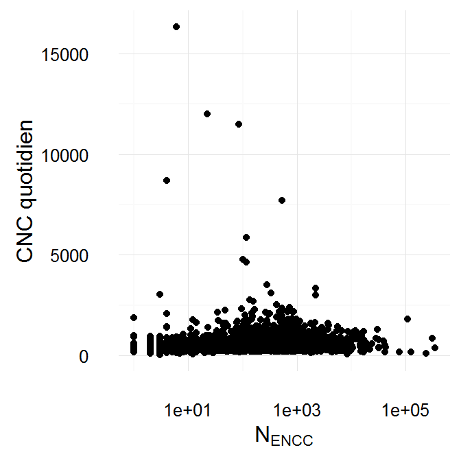

Figure 3 : $CCHR_{Q}$ (A) et $CNC_{Q}$ (B) en fonction de $N_{ENCC}$

Comme les GHMs avec moins de 200 patients sont exclus de l’ENCC ex-OQN, nous allons explorer le problème des faibles effectifs uniquement pour les établissements ex-DGF. Comme le montre la figure 3A la variabilité du $CCHR_{Q}$ semble augmenter pour des effectifs inférieurs à 50. Les quelques valeurs extrêmes du $CCHR_{Q}$ peuvent donc être causées par des problèmes d’échantillonage.

Par contre ce problème semble moins important pour le $CNC_{Q}$ (figure 3B), probablement car la variabilité de ce coût est de toute façon importante. Les valeurs extrêmes supérieurs à 5000 euros se retrouvent dans des GHMs avec des tailles d’échantillon variées, elle ne sont pas uniquement causées par des problèmes d’échantillonage. Elles correspondent à des poses de dispositifs spécialisés (implants cochléaires, pacemaker). Le coût élevé du dispositif explique le $CNC_{Q}$ important de ces GHMs. Comme le dispositif n’est implanté qu’une seule fois au cours du séjour, il est incorrect de rendre ce coût fonction du nombre de jours d’hospitalisation.

$CCR_{Q}$ : Pour évaluer le nombre de patients ayant contribué à l’estimation des coûts de réanimation dans l’ENCC, nous avons combiné les données de l’ENCC et du PMSI MCO. En effet l’ENCC ne donne que la DMS en réanimation $DMS_{REA}$ du GHM, et pas la proportion de patients du GHM a avoir séjourné en réanimation $P_{REA}$. Cette proportion a donc été estimée avec le PMSI MCO sur les séjours dans des établissements ex-DGF. Nous avons ensuite multiplié l’effectif ENCC par GHM par cette proportion pour obtenir $N_{REA}$, une estimation du nombre de patients qui sont passés en réanimation dans l’échantillon ENCC.

Mais la qualité de l’estimation du coût d’une journée de réanimation dépend surtout du nombre de journées de réanimation observées $NJ_{REA}$ dans le GHM, c’est à dire le produit de $N_{REA}$ par $DMS_{REA}$. Toutefois il faut garder à l’esprit que le coût des journées de réanimation sont probablement corrélées positivement pour un même patient. En pratique pour obtenir une bonne estimation du $CCR_{Q}$ d’un GHM, il faut à la fois un $N_{REA}$ élevé et un $NJ_{REA}$ élevé.

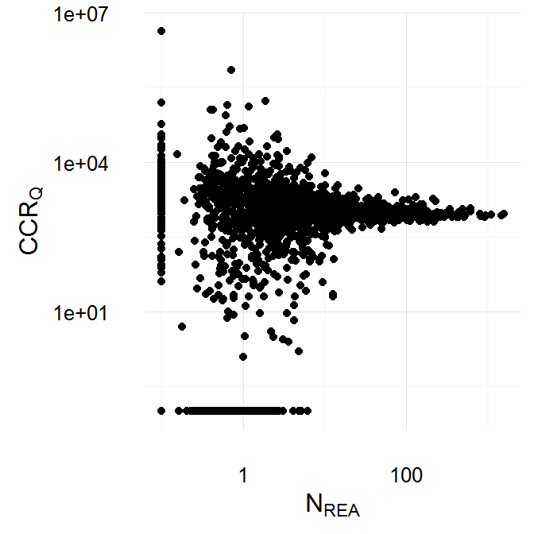

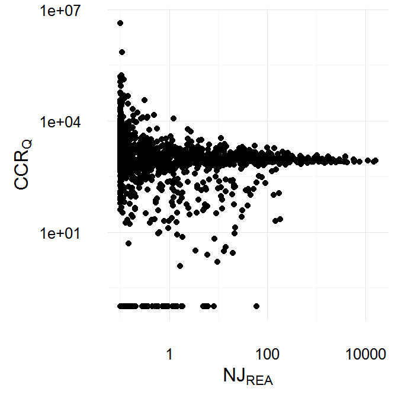

Figure 4 : $CCR_{Q}$ selon $N_{REA}$ (A) et $NJ_{REA}$ (B), échelle log-log.

Pour confirmer cette hypothèse nous avons examiné la variabilité des estimations des coûts cliniques quotidiens en réanimation $CCR_{Q}$ en fonction de $N_{REA}$ (figure 4A) et de $NJ_{REA}$ (figure 4B). Nous pouvons constater que la variabilité de $CCR_{Q}$ augmente fortement quand $N_{REA}$ et $NJ_{REA}$ diminuent. Si nous nous limitons aux GHM où $N_{REA}$ et $NJ_{REA}$ sont supérieurs à 50 , nous constatons que la variance et l’étendue du $CCR_{Q}$ diminue grandement (étendue de 632€ à 1846€, moyenne à 919€ $\pm$ 175€).

Les deux groupes de points longeant les axes sur la figure 4 correspondent aux GHM qui n’apparaissent que dans l’ENCC ou que dans le PMSI MCO.

Effectif empirique au delà duquel les estimations sont considérées de meilleur qualité.

## Solutions proposées

14. $$CCHR_{Q}^{*} =
    \begin{cases}
    CCHR_{Q} & \text{Si } 150 \geq CCHR_{Q} \geq 500 \\
    150 & \text{Si } CCHR_{Q} < 150 \\
    500 & \text{Si } CCHR_{Q} > 500
    \end{cases}$$

La première solution a l’avantage d’éviter de générer des valeurs abérentes tout en restant simple, mais l’inconvénient est que l’estimation restera mauvaise pour quelques rares GHM très spécifiques. La deuxième solution est plus exacte, mais plus complexe. En pratique, sauf étude spécifique sur les dispositifs coûteux concernés, il y a peu de raisons de ne pas utiliser la première méthode, formule (15).

15. $$CNC_{Q}^{*} =
    \begin{cases}
    CNC_{Q} & \text{Si } CNC_{Q} < 2500 \\
    2500 & \text{Si } CNC_{Q} > 2500
    \end{cases}$$

Les $CCR_{Q}$ semblent difficiles à estimer à partir de l’ENCC. Leur variation semble avant tout provoquée par des problèmes d’estimation. Cette variance est souvent très importante (pouvant aller du simple au quadruple) et peut fortement influencer l’estimation du coût des séjours. Comme $N_{REA}$ et $NJ_{REA}$ ne sont pas estimables à partir de l’ENCC seule, il n’est pas possible de savoir lors d’une analyse de coût si le $CCR_{Q}$ estimé est fiable.

Pour éviter ces problèmes nous proposons d’utiliser systématiquement comme estimation du coût d’une journée en réanimation la moyenne du $CCR_{Q}$ calculée sur les séjours qui permettent une estimation de bonne qualité : 919€. Cette estimation reste proche du tarif du supplément quotidien REA publié chaque année au journal officiel (809€ en 2011 par exemple). Toutefois il semblerait qu’utiliser le tarif du supplément REA conduise à une sous estimation du $CCR_{Q}$ d’environs 100€ par jour en moyenne.

L’ENCC ne fait pas de différences entre les réanimations adultes, les trois types de réanimations néonatales et la réanimation pédiatrique. Il n’est donc pas possible de calculer un $CCR_{Q}$ pour ces réanimations.

Pourtant le tarif d’un supplément quotidien en réanimation néonatale par exemple peut aller de 300€ pour une réanimation de type I à 900€ pour un type III. Nous pouvons supposer que ces tarifs sont une bonne approximation des coûts quotidiens, comme ils l’étaient pour la réanimation adulte. Il est donc possible d’affiner l’estimation du coût de la réanimation dans le séjour pour les réanimations pédiatriques ou néonatale en utilisant le tarif du forfait correspondant publié au journal officiel.

Comme le coût d’une journée en réanimation est imputé par une valeur fixe qui est la même pour tous les GHMs, une analyse de sensibilité peut être justifiée. Nous avons estimé la loi de probabilité suivie par le $CCR_{Q}$ mesurés par l’ENCC de la manière suivante :

- Nous avons sélectionnés les coûts dont l’estimation était d’une qualité satisfaisante ($N_{REA}$ et $NJ_{REA}$ supérieurs à 50) ;
- Nous avons transformé ces coût pour qu’ils commencent à 0 (voir figure 5A) ;

  En retirant au $CCR_{Q}$ sa valeur minimale, 630.
- Nous avons recherché une distribution de probabilité adpatée à la distribution de probabilité de $CCR_{Q}$, et nous avons estimé les paramètres ;
- Pour obtenir des $CCR_{Q}$ à partir de valeurs générées par cette distribution de probabilité il suffit ensuite d’effectuer la transformation inverse.

  Ajouter à $CCR_{Q}$ sa valeur minimale.

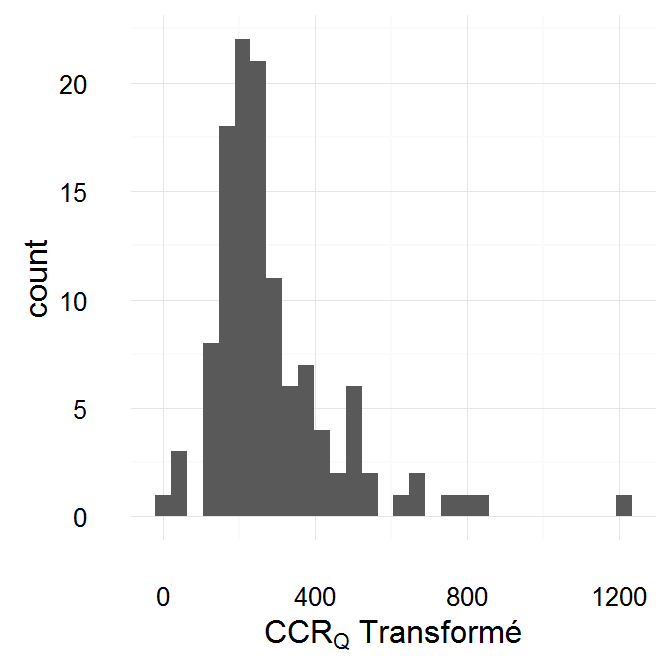

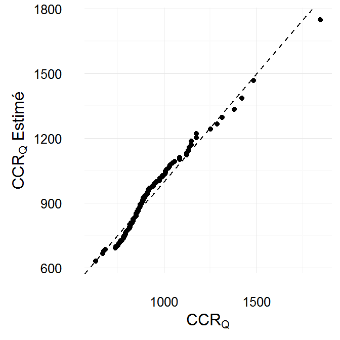

Figure 5 : $CCR_{Q}$ transformé (A) et correspondance à une distribution $\Gamma$ (B).

En pratique le $CCR_{Q}$ transformé suit une loi Gamma de paramètre d’échelle 2.8 et de paramètre d’intensité $9.7 \times 10^{-3}$. Le graphique quantile-quantile montre que la distribution estimée correspond bien à la distribution observée (voir figure 5B). Dans une analyse de sensibilité le $CCR_{Q}$ peut donc être tiré au sort avec la formule (16).

16. $$CCR_{Q} = R + 630 \text{ avec } R \sim \operatorname{\Gamma} \left({\alpha = 2.8,\ \beta = 9.7 \times 10^{-3}}\right)$$

# Formule définitive et synthèse

Il est donc possible de formuler un algorithme unifié permettant d’implémenter l’ensemble des corrections proposées dans les sections précédentes :

Durée moyenne de séjour selon l’ENCC :
$$DMS^{*} =
\begin{cases}
DMS & \text{Si } DMS \geq 1 \\
1 & \text{Si } DMS < 1
\end{cases}$$

Durée moyenne de séjour hors réanimation :
$$DMS_{HR} = DMS^{*} - DMS_{REA}$$

Coût clinique hors réanimation selon l’ENCC :
$$CCHR = DC + DSC + DSI$$
Avec $DC$ : Dépenses cliniques, $DSC$ : Dépenses SC, et $DSI$ : Dépenses SI.

Coût clinique quotidien hors réanimation :
$$CCHR_{Q} =
\begin{cases}
\frac{CCHR}{DMS_{HR}} & \text{Si } DMS_{HR} > 0 \\
0 & \text{Si } DMS_{HR} = 0
\end{cases}$$

Correction du coût clinique quotidien hors réanimation :
$$CCHR_{Q}^{*} =
\begin{cases}
CCHR_{Q} & \text{Si } 150 \geq CCHR_{Q} \geq 500 \\
150 & \text{Si } CCHR_{Q} < 150 \\
500 & \text{Si } CCHR_{Q} > 500
\end{cases}$$

Coût clinique quotidien en réanimation :
$$CCR_{Q} = 919$$

Ne pas oublier d’utiliser les valeurs des forfaits spécifiques publiées au journal officiel pour les réanimations néonatales et pédiatriques.

Coût non clinique selon l’ENCC :
$$CNC = CCHS + TS - CC$$
Avec $CCHS$ : Coût complet hors structure, $TS$ : Total Structure et $CC$ : Dépense des activités cliniques.

Coût non clinique quotidien :
$$CNC_{Q} = \frac{CNC}{DMS}$$

Correction du coût non clinique quotidien :
$$CNC_{Q}^{*} =
\begin{cases}
CNC_{Q} & \text{Si } CNC_{Q} < 2500 \\
2500 & \text{Si } CNC_{Q} > 2500
\end{cases}$$

Durée totale de séjour selon le PMSI : $D_{T}$.

Correction de la durée totale de séjour :
$$D_{T}^{*} =
\begin{cases}
D_{T} & \text{Si } D_{T} \geq 1 \\
1 & \text{Si } D_{T} < 1
\end{cases}$$

Durée de séjour en réanimation selon le PMSI : $D_{REA}$.

Ne pas oublier les durées en réanimations noéonatales et pédiatriques ici non plus.

Durée de séjour hors-réanimation :
$$D_{HR} = D_{T}^{*} - D_{REA}$$

Correction de la durée de séjour hors-réanimation :
$$D_{HR}^{*} =
\begin{cases}
D_{HR} & \text{Si } D_{HR} \geq 0 \\
0 & \text{Si } D_{HR} < 0
\end{cases}$$

Calcul du coût total ($CT$) du séjour :
$$CT = D_{REA} \times CCR_{Q} + D_{HR}^{*} \times CCHR_{Q}^{*} + D_{T}^{*} \times CNC_{Q}^{*}$$

Cette méthode d’estimation souffre de plusieurs problèmes :

- Comme nous calculons un coût d’hospitalisation par jour en hors-réani-mation en combinant l’hospitalisation clinique, la surveillance continue, et les soins intensifs nous faisons l’hypothèse que tous les séjours sont restés pendant la même durée de temps dans ces modes d’hospitalisation ;
- Pour les séjours qui peuvent durer zéro jours ou plus, le coût d’un séjour de zéro jour est considéré identique au coût d’un séjour d’un jour ;
- Les rares coûts extrêmes des GHM avec pose de matériel coûteux sont corrigés de manière très grossière ;
- Les coûts de réanimation ne sont pas estimés par GHM ;
- Les coûts de réanimation pédiatrique et néonatologique ne sont pas estimés à partir de l’ENCC.

Il est possible de prendre en compte certains de ces problèmes. Si l’étude de coût porte un intérêt particulier aux GHMs avec pose de matériel onéreux, alors il est justifié d’étudier avec plus d’attention les sections de l’ENCC concernant les dispositifs. Il est également possible d’effectuer des analyses de sensibilité en faisant varier les coûts de réanimation en utilisant la formule (16). Toutefois, cette technique est utilisable uniquement avec la réanimation adulte.

En conclusion, ce document modifie peu la formule originale d’estimation des coûts du point de vue de l’établissement, formule (8), mais il permet d’apporter une méthodologie standardisée permettent d’éviter certaines valeurs abérentes. De plus cette étude permet d’apprécier la nature des corrections empiriques apportées pour éviter les valeurs abérentes, mais aussi et surtout l’erreur qu’elles génèrent. Dans les cas où ces corrections génèrent une erreur importante, nous proposons des méthodes pour quantifier l’effet potentiel de ces erreurs par des études de sensibilité.